# ACTG175 (Continuous): Comparing Selection Rules

Parallel config: workers = 13 , batch_size = 20 Batch 1 / 1 : candidates 1 - 20 Evaluated 20 of 20 candidates (complete) 6 subgroups passed consistency threshold SG focus = hrMaxSG

============================================================================================================== CANDIDATE EVALUATION SUMMARY (sg_focus = “hrMaxSG”, selection_rule = “both”) ============================================================================================================== Rank MD N E K P OF IB S Subgroup ————————————————————————————————————– 1 82.783 87 87 2 0.990 * * * !{cd40 <= 396} & !{wtkg <= 82.3284} 2 85.916 61 61 2 0.990 * * - !{cd40 <= 506.6} & {age <= 35.2} 3 58.093 122 122 2 0.920 * - - !{cd40 <= 396} & !{wtkg <= 78.1} 4 66.396 110 110 2 0.950 * - - {age <= 35.2} & !{cd40 <= 449} 5 71.336 101 101 2 0.960 * - - {age <= 34} & !{cd40 <= 449} 6 76.583 99 99 2 0.990 * - - !{cd40 <= 396} & !{wtkg <= 81.2} ————————————————————————————————————– Evaluated: 20 Passed: 6 On frontier: 6 In band: 2 Selected: m=1 Legend: P = Pcons (consistency probability); OF = on Pareto frontier; IB = in effect-size band; S = selected. ==============================================================================================================

Seconds and minutes forestsearch overall = 12.239 0.204 Consistency algorithm used: twostage Subgroup identified: !{cd40 <= 396} & !{wtkg <= 82.3284}

````r
cat("\n```\n\n</details>\n")
````

[output not shown]

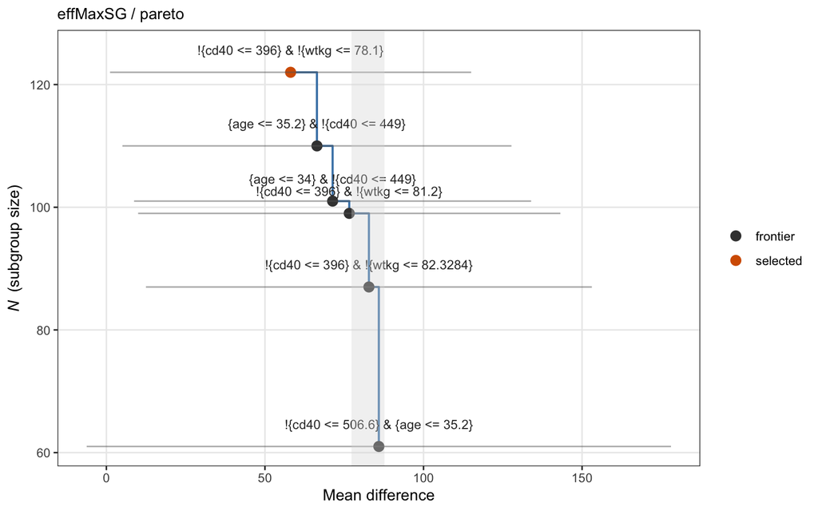

Pareto frontier — effMaxSG / pareto

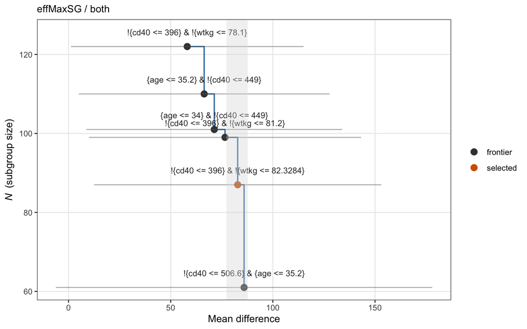

Pareto frontier — effMaxSG / both

```r
print(comparison$plots[[2]])
```

### 5.1.2 Side-by-Side Composition

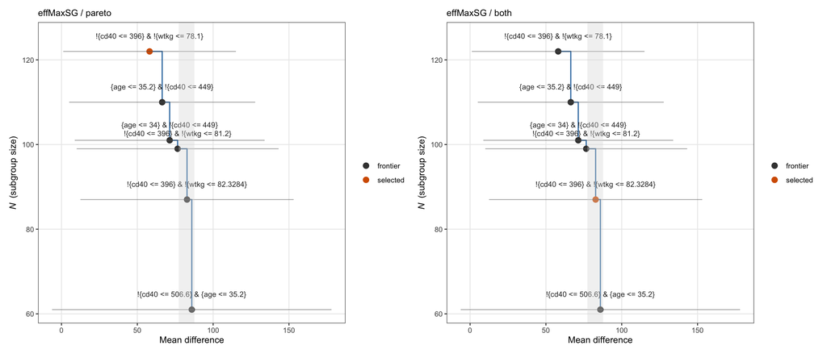

Pareto frontier across selection rules (side-by-side)

```r
print(comparison$plot_grid)
```

## 5.2 Combined Plot (when passing sets match)

When the two configurations produce the same passing set, the combined plot below labels each selected subgroup with one or more `S<i>:` markers naming the configuration(s) that picked it. When the sets differ, this returns `NULL` and the side-by-side view above is the appropriate alternative.

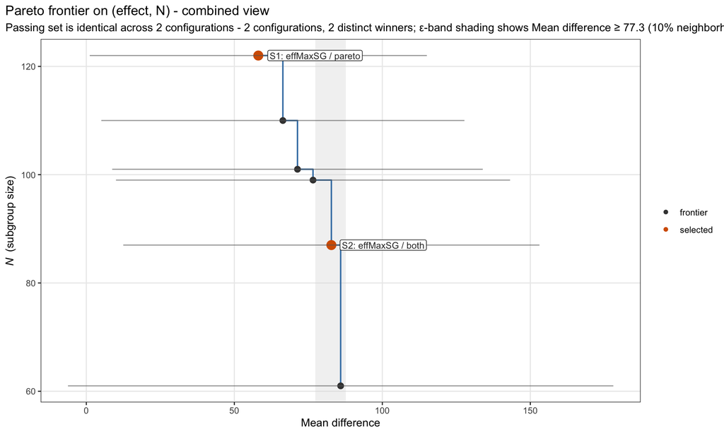

Combined Pareto frontier with S1/S2 winner annotations

```r
if (!is.null(comparison$plot_combined)) {
  print(comparison$plot_combined)
} else {
  cat("No combined plot: passing sets differ across configurations.\n")
  cat("See the side-by-side composition above instead.\n")
}
```

## 5.3 Frontier Tables

Per-combination Pareto-frontier table with split-derived and FSBC CIs. Selected subgroup is highlighted with ★.

### 5.3.1 effMaxSG / pareto

```r
pareto_frontier_table(
  comparison$fs[[1]],
  ci_table = comparison$ci_tab[[1]],
  digits   = frontier_params$digits
)
```

Pareto frontier on (MD, N)

6 non-dominated candidate(s) | sg_focus = 'hrMaxSG' | MD shown on natural scale | diagnostic only

| S<sup>1,2</sup> | M.1 | M.2 | N | E | MD | P<sup>3</sup> | K | 95% CIs Naive | 95% CIs Split ~ | 95% CIs FSBC ~ |
| --- | --- | --- | --- | --- | --- | --- | --- | --- | --- | --- |
|  | !{cd40 <= 506.6} | {age <= 35.2} | 61 | 61 | 85.92 | 0.91 | 2 | (-3.08, 174.91) | (-6.21, 178.04) | 85.72 (-6.41, 177.84) |
|  | !{cd40 <= 396} | !{wtkg <= 82.3284} | 87 | 87 | 82.78 | 0.97 | 2 | (14.81, 150.76) | (12.48, 153.09) | 82.55 (12.24, 152.85) |
|  | !{cd40 <= 396} | !{wtkg <= 81.2} | 99 | 99 | 76.58 | 0.99 | 2 | (11.95, 141.22) | (10.01, 143.15) | 76.64 (10.07, 143.21) |
|  | {age <= 34} | !{cd40 <= 449} | 101 | 101 | 71.34 | 0.95 | 2 | (10.21, 132.46) | (8.73, 133.94) | 71.46 (8.85, 134.06) |
|  | {age <= 35.2} | !{cd40 <= 449} | 110 | 110 | 66.40 | 0.97 | 2 | (8.65, 124.14) | (5.06, 127.74) | 66.35 (5.01, 127.69) |
| ★ | !{cd40 <= 396} | !{wtkg <= 78.1} | 122 | 122 | 58.09 | 0.92 | 2 | (3.17, 113.01) | (1.15, 115.04) | 58.14 (1.20, 115.08) |

<sup>1</sup> S: selected subgroup (winner of the configured selection rule).  
<sup>2</sup> ★ marks the subgroup chosen by sg_focus = 'hrMaxSG'.  
<sup>3</sup> P: Pcons (consistency probability).

### 5.3.2 effMaxSG / both

```r
pareto_frontier_table(
  comparison$fs[[2]],
  ci_table = comparison$ci_tab[[2]],
  digits   = frontier_params$digits
)
```

Pareto frontier on (MD, N)

6 non-dominated candidate(s) | sg_focus = 'hrMaxSG' | MD shown on natural scale | diagnostic only

| S<sup>1,2</sup> | M.1 | M.2 | N | E | MD | P<sup>3</sup> | K | 95% CIs Naive | 95% CIs Split ~ | 95% CIs FSBC ~ |
| --- | --- | --- | --- | --- | --- | --- | --- | --- | --- | --- |
|  | !{cd40 <= 506.6} | {age <= 35.2} | 61 | 61 | 85.92 | 0.99 | 2 | (-3.08, 174.91) | (-6.21, 178.04) | 85.72 (-6.41, 177.84) |
| ★ | !{cd40 <= 396} | !{wtkg <= 82.3284} | 87 | 87 | 82.78 | 0.99 | 2 | (14.81, 150.76) | (12.48, 153.09) | 82.55 (12.24, 152.85) |
|  | !{cd40 <= 396} | !{wtkg <= 81.2} | 99 | 99 | 76.58 | 0.99 | 2 | (11.95, 141.22) | (10.01, 143.15) | 76.64 (10.07, 143.21) |
|  | {age <= 34} | !{cd40 <= 449} | 101 | 101 | 71.34 | 0.96 | 2 | (10.21, 132.46) | (8.73, 133.94) | 71.46 (8.85, 134.06) |
|  | {age <= 35.2} | !{cd40 <= 449} | 110 | 110 | 66.40 | 0.95 | 2 | (8.65, 124.14) | (5.06, 127.74) | 66.35 (5.01, 127.69) |
|  | !{cd40 <= 396} | !{wtkg <= 78.1} | 122 | 122 | 58.09 | 0.92 | 2 | (3.17, 113.01) | (1.15, 115.04) | 58.14 (1.20, 115.08) |

<sup>1</sup> S: selected subgroup (winner of the configured selection rule).  
<sup>2</sup> ★ marks the subgroup chosen by sg_focus = 'hrMaxSG'.  
<sup>3</sup> P: Pcons (consistency probability).

## 5.4 Selection Narratives

`explain_pareto_selection()` produces a verbal account of why the selected subgroup wins on the configured lexicographic criterion relative to the other non-dominated candidates. Reading the two narratives together highlights which axis of the lex key the two rules tie-broke on differently.

### 5.4.1 effMaxSG / pareto

```r
cat(explain_pareto_selection(
  comparison$fs[[1]],
  ci_table = comparison$ci_tab[[1]],
  digits   = frontier_params$digits
))
```

**Selection criterion.** The configured criterion is largest-N among non-dominated candidates (sg_focus = “hrMaxSG”) under the Pareto-non-dominance rule. Within the eligible set, ties on N are broken by Pcons, then by effect strength, then by parsimony (smaller K).

**Selected subgroup.** !{cd40 <= 396} AND !{wtkg <= 78.1} (mean difference = 58.09, N = 122, Pcons = 0.92, K = 2). This is the largest-N candidate in the eligible set among non-dominated frontier candidates. The Naive 95% CI for the mean difference on this subgroup is (3.17, 113.01).

**Non-selected frontier candidates** (ordered by closeness to winning):

- **{age <= 35.2} AND !{cd40 <= 449}** (mean difference = 66.40, N = 110, Pcons = 0.97, K = 2). Smaller subgroup (N=110 vs N=122, 12 fewer subjects). N is the primary tiebreaker among non-dominated candidates, so this candidate’s stronger effect could not overcome the size loss.
- **{age <= 34} AND !{cd40 <= 449}** (mean difference = 71.34, N = 101, Pcons = 0.95, K = 2). Smaller subgroup (N=101 vs N=122, 21 fewer subjects). N is the primary tiebreaker among non-dominated candidates, so this candidate’s stronger effect could not overcome the size loss.
- **!{cd40 <= 396} AND !{wtkg <= 81.2}** (mean difference = 76.58, N = 99, Pcons = 0.99, K = 2). Smaller subgroup (N=99 vs N=122, 23 fewer subjects). N is the primary tiebreaker among non-dominated candidates, so this candidate’s stronger effect could not overcome the size loss.
- **!{cd40 <= 396} AND !{wtkg <= 82.3284}** (mean difference = 82.78, N = 87, Pcons = 0.97, K = 2). Smaller subgroup (N=87 vs N=122, 35 fewer subjects). N is the primary tiebreaker among non-dominated candidates, so this candidate’s stronger effect could not overcome the size loss.
- **!{cd40 <= 506.6} AND {age <= 35.2}** (mean difference = 85.92, N = 61, Pcons = 0.91, K = 2). Smaller subgroup (N=61 vs N=122, 61 fewer subjects). N is the primary tiebreaker among non-dominated candidates, so this candidate’s stronger effect could not overcome the size loss.

### 5.4.2 effMaxSG / both

```r
cat(explain_pareto_selection(
  comparison$fs[[2]],
  ci_table = comparison$ci_tab[[2]],
  digits   = frontier_params$digits
))
```

**Selection criterion.** The configured criterion is largest-N within the effect-size band (sg_focus = “hrMaxSG”) under the intersection of effect-band and Pareto-non-dominance rules. The effect-size band requires mean difference within 10% of the maximum on the frontier (i.e., mean difference >= 77.32). Within the eligible set, ties on N are broken by Pcons, then by effect strength, then by parsimony (smaller K).

**Selected subgroup.** !{cd40 <= 396} AND !{wtkg <= 82.3284} (mean difference = 82.78, N = 87, Pcons = 0.99, K = 2). This is the largest-N candidate in the eligible set among non-dominated frontier candidates. The Naive 95% CI for the mean difference on this subgroup is (14.81, 150.76).

**Non-selected frontier candidates** (ordered by closeness to winning):

- **!{cd40 <= 506.6} AND {age <= 35.2}** (mean difference = 85.92, N = 61, Pcons = 0.99, K = 2). Smaller subgroup (N=61 vs N=87, 26 fewer subjects). N is the primary tiebreaker once the band is satisfied, so this candidate’s stronger effect could not overcome the size loss.
- **!{cd40 <= 396} AND !{wtkg <= 81.2}** (mean difference = 76.58, N = 99, Pcons = 0.99, K = 2). fell outside the effect-size band (mean difference = 76.58 below the floor); excluded before the N tiebreaker even applies.
- **{age <= 34} AND !{cd40 <= 449}** (mean difference = 71.34, N = 101, Pcons = 0.96, K = 2). fell outside the effect-size band (mean difference = 71.34 below the floor); excluded before the N tiebreaker even applies.
- **{age <= 35.2} AND !{cd40 <= 449}** (mean difference = 66.40, N = 110, Pcons = 0.95, K = 2). fell outside the effect-size band (mean difference = 66.40 below the floor); excluded before the N tiebreaker even applies.
- **!{cd40 <= 396} AND !{wtkg <= 78.1}** (mean difference = 58.09, N = 122, Pcons = 0.92, K = 2). fell outside the effect-size band (mean difference = 58.09 below the floor); excluded before the N tiebreaker even applies.

# 6 Rich Post-Consistency View

The `include_dominated = TRUE` argument to `pareto_frontier_table()` shows **all** passing candidates (not just the frontier), with `on_frontier` and `in_band` flag columns added. This is the post-hoc analog of the `CANDIDATE EVALUATION SUMMARY` banner printed during the run.

### 6.0.1 effMaxSG / pareto

```r
pareto_frontier_table(
  comparison$fs[[1]],
  ci_table          = comparison$ci_tab[[1]],
  include_dominated = TRUE,
  digits            = frontier_params$digits
)
```

Pareto frontier on (MD, N)

6 non-dominated candidate(s) | sg_focus = 'hrMaxSG' | MD shown on natural scale | diagnostic only

| S<sup>1,2</sup> | M.1 | M.2 | N | E | MD | P<sup>3</sup> | K | OF<sup>4</sup> | 95% CIs Naive | 95% CIs Split ~ | 95% CIs FSBC ~ |
| --- | --- | --- | --- | --- | --- | --- | --- | --- | --- | --- | --- |
| ★ | !{cd40 <= 396} | !{wtkg <= 78.1} | 122 | 122 | 58.09 | 0.92 | 2 | ★ | (3.17, 113.01) | (1.15, 115.04) | 58.14 (1.20, 115.08) |
|  | {age <= 35.2} | !{cd40 <= 449} | 110 | 110 | 66.40 | 0.97 | 2 | ★ | (8.65, 124.14) | (5.06, 127.74) | 66.35 (5.01, 127.69) |
|  | {age <= 34} | !{cd40 <= 449} | 101 | 101 | 71.34 | 0.95 | 2 | ★ | (10.21, 132.46) | (8.73, 133.94) | 71.46 (8.85, 134.06) |
|  | !{cd40 <= 396} | !{wtkg <= 81.2} | 99 | 99 | 76.58 | 0.99 | 2 | ★ | (11.95, 141.22) | (10.01, 143.15) | 76.64 (10.07, 143.21) |
|  | !{cd40 <= 396} | !{wtkg <= 82.3284} | 87 | 87 | 82.78 | 0.97 | 2 | ★ | (14.81, 150.76) | (12.48, 153.09) | 82.55 (12.24, 152.85) |
|  | !{cd40 <= 506.6} | {age <= 35.2} | 61 | 61 | 85.92 | 0.91 | 2 | ★ | (-3.08, 174.91) | (-6.21, 178.04) | 85.72 (-6.41, 177.84) |

<sup>1</sup> S: selected subgroup (winner of the configured selection rule).  
<sup>2</sup> ★ marks the subgroup chosen by sg_focus = 'hrMaxSG'.  
<sup>3</sup> P: Pcons (consistency probability).  
<sup>4</sup> OF: on Pareto frontier (non-dominated on (effect, N)).

### 6.0.2 effMaxSG / both

```r
pareto_frontier_table(
  comparison$fs[[2]],
  ci_table          = comparison$ci_tab[[2]],
  include_dominated = TRUE,
  digits            = frontier_params$digits
)
```

Pareto frontier on (MD, N)

6 non-dominated candidate(s) | sg_focus = 'hrMaxSG' | MD shown on natural scale | diagnostic only

| S<sup>1,2</sup> | M.1 | M.2 | N | E | MD | P<sup>3</sup> | K | OF<sup>4</sup> | IB<sup>5</sup> | 95% CIs Naive | 95% CIs Split ~ | 95% CIs FSBC ~ |
| --- | --- | --- | --- | --- | --- | --- | --- | --- | --- | --- | --- | --- |
| ★ | !{cd40 <= 396} | !{wtkg <= 82.3284} | 87 | 87 | 82.78 | 0.99 | 2 | ★ | ★ | (14.81, 150.76) | (12.48, 153.09) | 82.55 (12.24, 152.85) |
|  | !{cd40 <= 506.6} | {age <= 35.2} | 61 | 61 | 85.92 | 0.99 | 2 | ★ | ★ | (-3.08, 174.91) | (-6.21, 178.04) | 85.72 (-6.41, 177.84) |
|  | !{cd40 <= 396} | !{wtkg <= 78.1} | 122 | 122 | 58.09 | 0.92 | 2 | ★ |  | (3.17, 113.01) | (1.15, 115.04) | 58.14 (1.20, 115.08) |
|  | {age <= 35.2} | !{cd40 <= 449} | 110 | 110 | 66.40 | 0.95 | 2 | ★ |  | (8.65, 124.14) | (5.06, 127.74) | 66.35 (5.01, 127.69) |
|  | {age <= 34} | !{cd40 <= 449} | 101 | 101 | 71.34 | 0.96 | 2 | ★ |  | (10.21, 132.46) | (8.73, 133.94) | 71.46 (8.85, 134.06) |
|  | !{cd40 <= 396} | !{wtkg <= 81.2} | 99 | 99 | 76.58 | 0.99 | 2 | ★ |  | (11.95, 141.22) | (10.01, 143.15) | 76.64 (10.07, 143.21) |

<sup>1</sup> S: selected subgroup (winner of the configured selection rule).  
<sup>2</sup> ★ marks the subgroup chosen by sg_focus = 'hrMaxSG'.  
<sup>3</sup> P: Pcons (consistency probability).  
<sup>4</sup> OF: on Pareto frontier (non-dominated on (effect, N)).  
<sup>5</sup> IB: in effect-size neighborhood band.

# 7 Programmatic Access (Reference)

```r
# Each combination's full fs object is available for downstream use:
comparison$fs[[1]]       # selection_rule = "pareto"
comparison$fs[[2]]       # selection_rule = "both"

# CI tables (data.tables):
comparison$ci_tab[[1]]
comparison$ci_tab[[2]]

# Plot objects (ggplot):
comparison$plots[[1]]
comparison$plots[[2]]

# Console output (full captured stdout, one character per line):
comparison$console[[1]]
comparison$console[[2]]

# Diagnostics (filtered slices: preview, summary, full):
comparison$diagnostics[[1]]$preview     # PREVIEW block as single string
comparison$diagnostics[[1]]$summary     # SUMMARY block as single string
comparison$diagnostics[[1]]$full        # entire captured stdout (single string)

# Errors (NULL if combo succeeded):
comparison$errors[[1]]
comparison$errors[[2]]

# The combos data.frame:
comparison$combos
```

# 8 Computational Timing

```r
timings$total <- (proc.time() - t_doc_start)["elapsed"]

timing_df <- data.frame(
  Component = c("Comparison run (both combos)", "Total document"),
  Seconds   = c(timings$compare, timings$total)
)
timing_df$Minutes <- timing_df$Seconds / 60

gt(timing_df) |>
  tab_header(title = "Computational Timing") |>
  fmt_number(columns = c(Seconds, Minutes), decimals = 1) |>
  cols_label(
    Component = "Component",
    Seconds   = "Time (sec)",
    Minutes   = "Time (min)"
  )
```

Computational Timing

| Component | Time (sec) | Time (min) |
| --- | --- | --- |
| Comparison run (both combos) | 36.9 | 0.6 |
| Total document | 38.5 | 0.6 |

# 9 References

León LA, Ye J, Zhao H. *A Bootstrap Framework for Subgroup Identification in Randomized Clinical Trials with Bias Correction.* Statistics in Medicine. 2024. [doi:10.1002/sim.10163](https://doi.org/10.1002/sim.10163)